# Pivoting: Wide and Long

Author

Robert W. Walker

# Overarching Theme

In a 2014 paper in the **Journal of Statistical Software**, {citation: Wickham, H. (2014). Tidy Data. Journal of Statistical Software, 59(10), 1–23. [DOI](https://doi.org/10.18637/jss.v059.i10)} available from the [following link](https://www.jstatsoft.org/article/view/v059i10), Hadley Wickham provides the following succinct definition of **tidy data** – data that accords with three key properties.

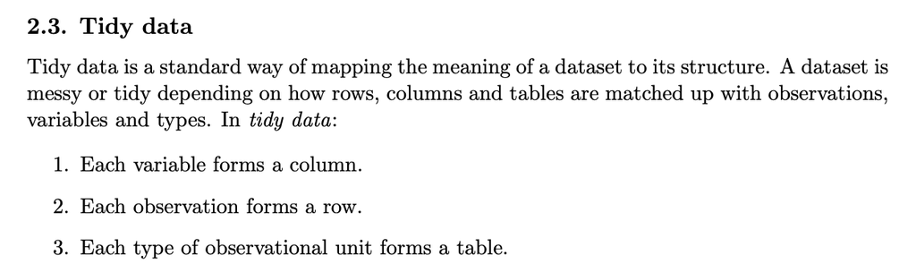

tidy data

The raison d’etre for pivoting operations examined in this post is the manipulation of *untidy* data into a tidy format. In his article, Hadley discusses five key ways that data are typically **untidy** though this is far from an exhaustive list [Wickham, p. 5]

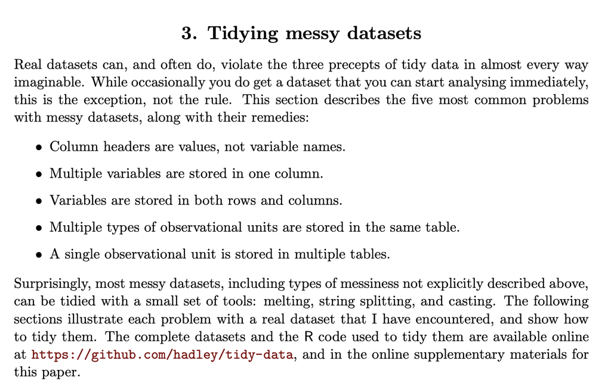

Five untidy tendencies

# Package and Some Details

The tidyverse collection contains two types of two `pivot_` operations: `pivot_wider` and `pivot_longer` for transforming data from long to wide [`pivot_wider`] and wide to long [`pivot_longer`] formats in the `library(tidyr)`. This quarto document will examine them and their use.

1. let us verify that they are a part of the `tidyverse`. You will notice `tidyr` among the packages being attached.

```r
library(tidyverse)
```

2. They are accompanied by a **vignette**; a vignette is essentially an extended help file to detail the use of some R commands. It can be accessed by making certain that the `tidyverse` [or just `tidyr`] is loaded [with either `library(tidyverse)` or `library(tidyr)`] and then

```
vignette("pivot")
```

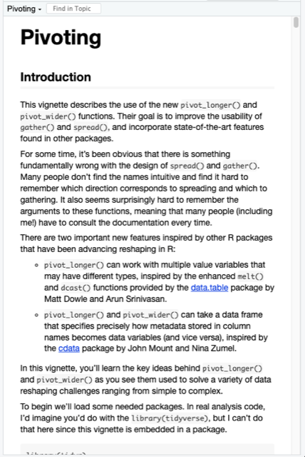

A view of the vignette obtained by vignette(“pivot”)

The data is contained in the packages so you can follow along and experiment with it, if you so choose. Some of the examples overlap with the paper cited above.

I want to first use an example deploying familiar data: the dataset on Bond Funds. Let’s load it and I will use `datatable` from the `DT` package to display it.

```r
library(DT)
load(url("https://github.com/robertwwalker/DADMStuff/raw/master/Week-3-Data.RData"))
datatable(Bonds)
```

|  | Fund.Number | Type | Assets | Fees | Expense.Ratio | Return.2009 | X3.Year.Return | X5.Year.Return | Risk |
| --- | --- | --- | --- | --- | --- | --- | --- | --- | --- |
| 1 | FN-1 | Intermediate Government | 7268.1 | No | 0.45 | 6.9 | 6.9 | 5.5 | Below average |
| 2 | FN-2 | Intermediate Government | 475.1 | No | 0.5 | 9.8 | 7.5 | 6.1 | Below average |
| 3 | FN-3 | Intermediate Government | 193 | No | 0.71 | 6.3 | 7 | 5.6 | Average |
| 4 | FN-4 | Intermediate Government | 18603.5 | No | 0.13 | 5.4 | 6.6 | 5.5 | Average |
| 5 | FN-5 | Intermediate Government | 142.6 | No | 0.6 | 5.9 | 6.7 | 5.4 | Average |
| 6 | FN-6 | Intermediate Government | 1401.6 | No | 0.54 | 5.7 | 6.4 | 6.2 | Average |
| 7 | FN-7 | Intermediate Government | 985.6 | No | 0.49 | 3 | 6.8 | 5.3 | Average |
| 8 | FN-8 | Intermediate Government | 2188.8 | No | 0.55 | 7.4 | 6.4 | 5.2 | Below average |
| 9 | FN-9 | Intermediate Government | 390.6 | No | 0.67 | 5.3 | 6.1 | 5 | Below average |
| 10 | FN-10 | Intermediate Government | 544.1 | No | 0.63 | 5.7 | 6.2 | 5.1 | Below average |

[output cut: 174 more lines]

# A Tidy Table

Let me create a table to work with as a very small and manageable example to illustrate the concepts. I will create a table of **Risk** and **Fees** and then turn it into an R `data.frame`.

```r
table(Bonds$Fees, Bonds$Risk) %>% data.frame()
```

```
  Var1          Var2 Freq
1   No Above average   37
2  Yes Above average   22
3   No       Average   49
4  Yes       Average   20
5   No Below average   44
6  Yes Below average   12
```

This is **tidy** though the names are bad but that can be fixed. Let me store this **long** table as an object to manipulate and fix the names. **Long** and **tidy** are largely interchangeable in the way that I use the terms. Without further ado, here is the example.

```r
Bonds.Table.Long <- table(Bonds$Fees, Bonds$Risk) %>%
  data.frame() %>%
  rename(Fees = Var1, Risk = Var2, Count = Freq)
Bonds.Table.Long
```

```
  Fees          Risk Count
1   No Above average    37
2  Yes Above average    22
3   No       Average    49
4  Yes       Average    20
5   No Below average    44
6  Yes Below average    12
```

Why is this tidy? It contains three variables: **Risk**, **Fees**, and a **Count** of the number of Bond Funds for each pair of **Risk** and **Fees**.

## Pivoting from Long to Wide

For display and because it is the most common way of seeing a table, I want to pivot it to wide form. Basically, I want to create a 2 (**Fees**) by 3 (**Risk**) table with the values of **Fees** on the rows and the values of **Risk** on the Columns and each cell representing the number of Funds for that row-column pair. *I should note it will actually be two-by-four because Fees is a margin of the table but the labels are treated as a variable.* I will need to start with the `Bonds.Table.Long` above and create named columns from the categories of **Risk** with values drawn from the counts of the number of funds with that combination of characteristics. The two key arguments in this case are where do the names come from `names_from` which is **Risk** and where do the values come from `values_from` which will be **Count**.

```r
Bonds.Table.Wide <- Bonds.Table.Long %>%
  pivot_wider(names_from=Risk, values_from=Count)
Bonds.Table.Wide
```

```
# A tibble: 2 × 4
  Fees  `Above average` Average `Below average`
  <fct>           <int>   <int>           <int>
1 No                 37      49              44
2 Yes                22      20              12
```

Wide data has “data” in the column names and the tidyverse and tidy data analysis are built upon the idea that we have *units* and *variables*, this has information on the *units* in the column names. Another way of putting it is that the values of **Risk** are spread across multiple columns of values. A proper *unit* here would be a Fee-Risk pair [now that we have tabulated the data and left the raw data behind]. But that information is spread across rows and columns.

## Pivoting from Wide to Long

To tidy these data, I need to put that data back into a **row-centric** format.

Let me use `pivot_longer` for that. Here, I need to tell R what variable the column names need to become (in quotes) and what variable the values need to become (also in quotes). I want the names of variables currently called `Above Average, Average, Below Average` to become [or re-become] **Risk** and the values to become **Count** because they will measure how many bond funds in the original data represent that Fee-Risk pair. **I should point out that spaces in column names are a nightmare. I would have been far better off to fix them while they are values of the Risk variable before pivoting but I did not. To address them, I will need tickmarks** I will show three ways to do this.

1. Negation because I want to pivot every column but **Fees**.
2. I will enclose them in tickmarks.
3. I will fix the names using `janitor` and its `clean_names` function.

**Negation**

First, let me do it by just telling R to use ! [not] Fees.

```r
BTL <- Bonds.Table.Wide %>%
  pivot_longer(cols= -Fees,
               names_to = "Risk",
               values_to = "Count")
BTL
```

```
# A tibble: 6 × 3
  Fees  Risk          Count
  <fct> <chr>         <int>
1 No    Above average    37
2 No    Average          49
3 No    Below average    44
4 Yes   Above average    22
5 Yes   Average          20
6 Yes   Below average    12
```

**Tickmarks**

```r
BTL2 <- Bonds.Table.Wide %>%
  pivot_longer(cols=c(`Above average`,Average,`Below average`),
               names_to = "Risk",
               values_to = "Count")
BTL2
```

```
# A tibble: 6 × 3
  Fees  Risk          Count
  <fct> <chr>         <int>
1 No    Above average    37
2 No    Average          49
3 No    Below average    44
4 Yes   Above average    22
5 Yes   Average          20
6 Yes   Below average    12
```

**Cleaned Names**

If we want to clean the names, a package introduced in class for tables using the pipe operator – the `janitor` package and its `tabyl` function – gives us a useful function called `clean_names`; it has a few arguments and is quite useful for transliteration from non-ASCII character sets, also. The default is the “snake” case that will replace the spaces with underscores. There are quite a few options for the argument, you can explore them by changing the argument among the options in quotations below. Be careful about curly quotes and such, they are not valid ASCII characters and computer languages will complain. The options are:

`"snake", "small_camel", "big_camel", "screaming_snake", "parsed", "mixed", "lower_upper", "upper_lower", "swap", "all_caps", "lower_camel", "upper_camel", "internal_parsing", "none", "flip", "sentence", "random", "title"`

I intend to use the “mixed” type which maintains the capitalization but replaces spaces with `_` which is as close as I can get to the initial names with spaces while separating the lines. Camel case would eliminate the spaces.

```r
library(janitor)
Bonds.Table.Wide.Clean <- Bonds.Table.Wide %>%
  clean_names("mixed")
```

Now I have names that I don’t need tickmarks for. I want to make the columns `Above_average, Average,` and `Below_average` into the categories of the **Risk** variable with values going into **Count**.

```r
BTL3 <- Bonds.Table.Wide.Clean %>%
  pivot_longer(cols=c(Above_average,Average,Below_average),
               names_to = "Risk",
               values_to = "Count")
BTL3
```

```
# A tibble: 6 × 3
  Fees  Risk          Count
  <fct> <chr>         <int>
1 No    Above_average    37
2 No    Average          49
3 No    Below_average    44
4 Yes   Above_average    22
5 Yes   Average          20
6 Yes   Below_average    12
```

# A More Complicated Example From the Wild: Intel 10-k

I am going to use an Intel [INTC] Income Statement that I obtained from their website. I chose the most recent one in Excel format which I have posted to my Github along with the income statement as .csv.

- [Download the Excel file](https://github.com/robertwwalker/DADMStuff/raw/master/Intel_Financial_Report-2022.xlsx)
- [Download the Single Income Statement Sheet Extracted and Saved as .csv](https://github.com/robertwwalker/DADMStuff/raw/master/Intel_Financial_Report-2022-IS.csv)
- [View the .csv on Github](https://github.com/robertwwalker/DADMStuff/blob/master/Intel_Financial_Report-2022-IS.csv)

I want to import the data from .csv. If you follow the link above to view the Income Statement on Github you will see the extracted .csv file.

```r
library(readr)
Intel.IS <- read_csv("https://github.com/robertwwalker/DADMStuff/raw/master/Intel_Financial_Report-2022-IS.csv", col_names = FALSE)
Intel.IS
```

```
# A tibble: 23 × 4
   X1                                                          X2    X3    X4
   <chr>                                                       <chr> <chr> <chr>
 1 Consolidated Statements of Income - USD ($) shares in Mill… 12 M… <NA>  <NA>
 2 <NA>                                                        Dec.… Dec.… Dec.…
 3 Income Statement [Abstract]
 4 Net revenue                                                 $ 63… $ 79… $ 77…
 5 Cost of sales                                               36,1… 35,2… 34,2…
 6 Gross margin                                                26,8… 43,8… 43,6…
 7 Research and development                                    17,5… 15,1… 13,5…
 8 Marketing, general and administrative                       7,002 6,543 6,180
 9 Restructuring and other charges                             2     2,626 198
10 Operating expenses                                          24,5… 24,3… 19,9…
# … with 13 more rows
```

First, notice three identification lines that I will want to drop, lines 1, 3, and 21. By default, `read_csv` makes the column names out of the first row. I have turned that off here to get the row numbers to match the .csv file. There are also some dollar signs and commas separating the amounts for formatting purposes that I need to fix; they currently prevent the data from being read as numeric. For now, I will skip line 1 (`skip=1`) and force the columns to be character, numeric, numeric, numeric; `read_csv` abbreviates those with quoted “cnnn”: `col_types="cnnn"`. I also want to trim whitespaces with `trim_ws=T` I learned this from the help.

```r
Intel.IS <- read_csv("https://github.com/robertwwalker/DADMStuff/raw/master/Intel_Financial_Report-2022-IS.csv", skip=1, col_types = "cnnn", trim_ws=T)
```

```
Warning: One or more parsing issues, call `problems()` on your data frame for details,
e.g.:
  dat <- vroom(...)
  problems(dat)
```

```r
datatable(Intel.IS)
```

|  | ...1 | Dec. 31, 2022 | Dec. 25, 2021 | Dec. 26, 2020 |
| --- | --- | --- | --- | --- |
| 1 | Income Statement [Abstract] |  |  |  |
| 2 | Net revenue | 63054 | 79024 | 77867 |
| 3 | Cost of sales | 36188 | 35209 | 34255 |
| 4 | Gross margin | 26866 | 43815 | 43612 |
| 5 | Research and development | 17528 | 15190 | 13556 |
| 6 | Marketing, general and administrative | 7002 | 6543 | 6180 |
| 7 | Restructuring and other charges | 2 | 2626 | 198 |
| 8 | Operating expenses | 24532 | 24359 | 19934 |
| 9 | Operating income | 2334 | 19456 | 23678 |
| 10 | Gains (losses) on equity investments, net | 4268 | 2729 | 1904 |

[output cut: 11 more lines]

There are still warnings. Data in the wild are messy but these are understandable. The warnings tell me that I can run a command called `problems` from the `vroom` library to discover them.

```r
library(vroom)
problems(Intel.IS)
```

```
# A tibble: 6 × 5
    row   col expected actual file
  <int> <int> <chr>    <chr>  <chr>
1     2     2 a number        ""
2     2     3 a number        ""
3     2     4 a number        ""
4    20     2 a number        ""
5    20     3 a number        ""
6    20     4 a number        ""
```

Those are the original rows 3 and 21 that I wished to skip (recall I skipped 1 and the column names are drawn from row 2 of the original .csv file). I have one unnamed column and three columns that are named by the date of the Income Statement. Let me rename the unnamed column to be Entry and then filter out the rows with **Entry** equal to “Income Statement [Abstract]” and “Weighted average shares of common stock outstanding:” as those are the identified issues.

```r
Intel.IS.Clean <- Intel.IS %>%
  rename(Entry = ...1) %>%
  filter(!(Entry %in% c("Income Statement [Abstract]","Weighted average shares of common stock outstanding:")))
```

Let’s view what we have now.

```r
datatable(Intel.IS.Clean)
```

|  | Entry | Dec. 31, 2022 | Dec. 25, 2021 | Dec. 26, 2020 |
| --- | --- | --- | --- | --- |
| 1 | Net revenue | 63054 | 79024 | 77867 |
| 2 | Cost of sales | 36188 | 35209 | 34255 |
| 3 | Gross margin | 26866 | 43815 | 43612 |
| 4 | Research and development | 17528 | 15190 | 13556 |
| 5 | Marketing, general and administrative | 7002 | 6543 | 6180 |
| 6 | Restructuring and other charges | 2 | 2626 | 198 |
| 7 | Operating expenses | 24532 | 24359 | 19934 |
| 8 | Operating income | 2334 | 19456 | 23678 |
| 9 | Gains (losses) on equity investments, net | 4268 | 2729 | 1904 |
| 10 | Interest and other, net | 1166 | 482 | 504 |

[output cut: 9 more lines]

That’s good. Now to pivot this. After pivoting, I want to mutate the period variable to be a proper date format. I also want to change the Entry to a factor variable so that the filter option in `datatable` will allow us to see just one accounting item by clicking on the available options – Click in the box **All** at the top of the column **Entry** to see the scroll menu. `datatable` has many neat features.

```r
Intel.Tidy <- Intel.IS.Clean %>% pivot_longer(cols=c(`Dec. 31, 2022`,`Dec. 25, 2021`,`Dec. 26, 2020`), names_to = "period", values_to = "Quantity") %>% mutate(Entry = as.factor(Entry), date = as.Date(period, format="%b. %d,%Y"))
datatable(Intel.Tidy, filter = "top")
```

|  | Entry | period | Quantity | date |
| --- | --- | --- | --- | --- |
| 1 | Net revenue | Dec. 31, 2022 | 63054 | 2022-12-31 |
| 2 | Net revenue | Dec. 25, 2021 | 79024 | 2021-12-25 |
| 3 | Net revenue | Dec. 26, 2020 | 77867 | 2020-12-26 |
| 4 | Cost of sales | Dec. 31, 2022 | 36188 | 2022-12-31 |
| 5 | Cost of sales | Dec. 25, 2021 | 35209 | 2021-12-25 |
| 6 | Cost of sales | Dec. 26, 2020 | 34255 | 2020-12-26 |
| 7 | Gross margin | Dec. 31, 2022 | 26866 | 2022-12-31 |
| 8 | Gross margin | Dec. 25, 2021 | 43815 | 2021-12-25 |
| 9 | Gross margin | Dec. 26, 2020 | 43612 | 2020-12-26 |
| 10 | Research and development | Dec. 31, 2022 | 17528 | 2022-12-31 |

[output cut: 47 more lines]

## Plot Some Financials

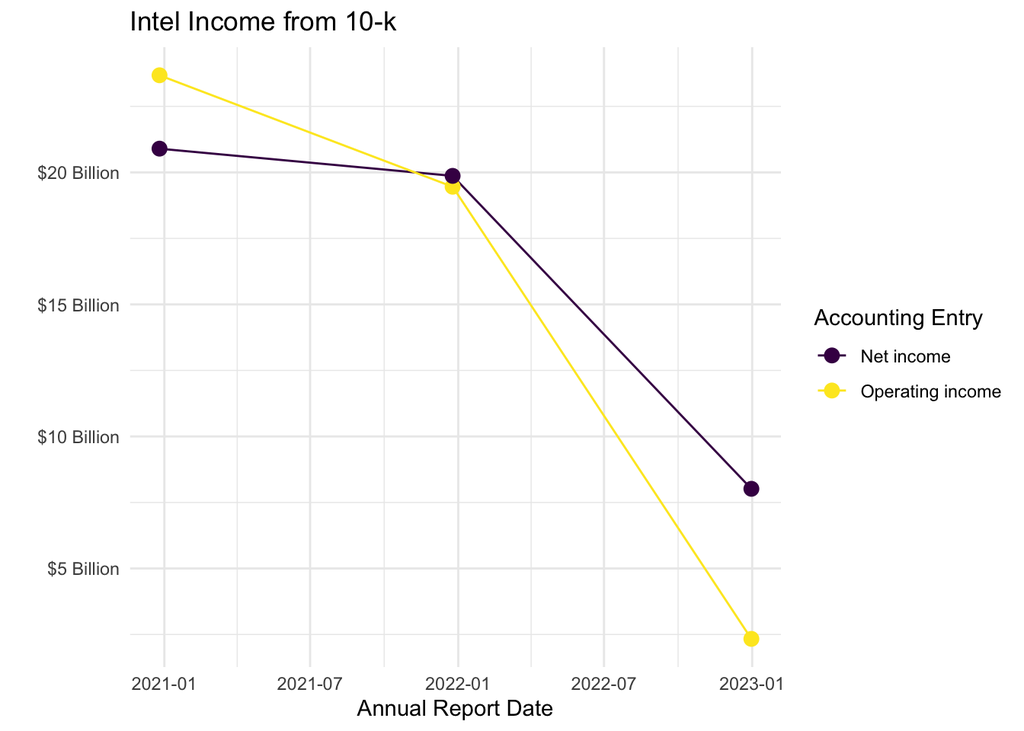

```r
library(scales)
Intel.Tidy %>% filter(Entry %in% c("Net income","Operating income")) %>%
  ggplot() +
  aes(x=date, y=Quantity, color=Entry) +
  geom_line() +
  geom_point(size=3) +
  theme_minimal() +
  scale_x_date() +
  scale_y_continuous(labels = label_dollar(suffix=" Billion", scale=1e-3)) +
  labs(title="Intel Income from 10-k", x="Annual Report Date", color="Accounting Entry", y="") +
  scale_color_viridis_d()
```

# A Really Wide and Messy Example: Weather

The following weather.gov site contains [Portland’s weather almanac](https://www.weather.gov/wrh/climate?wfo=pqr). A link to a csv of all the data can be downloaded directly into R. The datatable is huge because it covers four types of data – high, low, precipitation, and snow, from October 1940 to the present. It’s also got some random characters in it that are undefined.

```r
NWS <- read.csv(url("https://www.weather.gov/source/pqr/climate/webdata/Portland_dailyclimatedata.csv"), skip=6, na.strings = c("M","-")) %>%
  rename(Variable = X)
head(NWS, 10)
```

```
     YR MO Variable   X1   X2   X3   X4   X5   X6   X7   X8   X9  X10  X11  X12
1  1940 10       TX <NA> <NA> <NA> <NA> <NA> <NA> <NA> <NA> <NA> <NA> <NA> <NA>
2  1940 10       TN <NA> <NA> <NA> <NA> <NA> <NA> <NA> <NA> <NA> <NA> <NA> <NA>
3  1940 10       PR <NA> <NA> <NA> <NA> <NA> <NA> <NA> <NA> <NA> <NA> <NA> <NA>
4  1940 10       SN <NA> <NA> <NA> <NA> <NA> <NA> <NA> <NA> <NA> <NA> <NA> <NA>
5  1940 11       TX   52   53   47   55   51   58   56   50   48   47   46   45
6  1940 11       TN   40   38   36   32   42   46   46   42   35   34   35   33
7  1940 11       PR 0.17 0.02    T    0 0.07 0.28 0.85 0.29 0.02 0.01 0.01    0
8  1940 11       SN    0    0    0    0    0    0    0    0    0    0    0    0
9  1940 12       TX   51   53   52   51   56   54   50   51   48   50   46   45
10 1940 12       TN   42   40   42   42   44   37   34   35   32   26   34   28
    X13 X14 X15 X16  X17  X18 X19  X20  X21 X22  X23  X24 X25 X26  X27  X28
1    75  70  64  72   72   78  78   64   63  61   58   57  57  57   56   53
2    57  53  52  50   58   58  59   54   48  41   53   48  41  38   37   45
3  0.01   T   T   0 0.13    0   T 0.14 0.05   0 0.63 1.03   0   0    T 0.18
```

[output cut: 18 more lines]

Days of the month are most of the variable names. There is also a YR – year, a MO – month, and what variable – TX is high temperature, TN is low temperature, PR is precipitation, and SN is snow. To get this workable, I will need both a `pivot_longer` and a `pivot_wider`. What I want is a date column, high, low, precipitation, and snow.

### Removing Junk

One thing that will prove troublesome is that `/A` appears in a few places. I want to remove it. I will ask R to find all of the character columns and remove `/A`. I believe that this stands for trace accumulation. `where` is a helper to select columns with a set of characteristics and across allows me to transform those column-wise for all matching columns.

```r
NWS <- NWS %>% mutate(across(where(is.character), ~str_remove(.x, "/A")))
```

Now those are gone. Now a few other cleaning steps. I first create a daily dataset by removing the Averages/Totals which are the last column. I also want to rename the columns to `Day.*` rather than `X*` for numbers 1 to 31.

```r
NWS.Daily <- NWS %>% select(-AVG.or.Total)
names(NWS.Daily) <- c("YR","MO","Variable",paste0("Day.",1:31))
```

Now I can pivot the to long form of the data by choosing to pivot all columns that start with **Day.**

```r
NWS.Daily <- NWS.Daily %>%
  pivot_longer(., cols=starts_with("Day."), names_to = "Day", values_to = "value")
head(NWS.Daily)
```

```
# A tibble: 6 × 5
     YR    MO Variable Day   value
  <int> <int> <chr>    <chr> <chr>
1  1940    10 TX       Day.1 <NA>
2  1940    10 TX       Day.2 <NA>
3  1940    10 TX       Day.3 <NA>
4  1940    10 TX       Day.4 <NA>
5  1940    10 TX       Day.5 <NA>
6  1940    10 TX       Day.6 <NA>
```

```r
NWS.Daily <- NWS.Daily %>%
  mutate(Day = str_remove(Day, "Day.")) %>%
  pivot_wider(.,
              names_from = "Variable",
              values_from = "value") %>%
  mutate(PR = recode(PR, T = "O.005"),
         SN = recode(SN, T = "O.005")) %>%
  mutate(TX = as.numeric(TX),
         TN = as.numeric(TN),
         PR = as.numeric(PR),
         SN = as.numeric(SN),
         date = as.Date(paste(MO,Day,YR,sep="-"), format="%m-%d-%Y")
         )
NWS.Daily %>% filter(is.na(date))
```

```
# A tibble: 535 × 8
      YR    MO Day      TX    TN    PR    SN date
   <int> <int> <chr> <dbl> <dbl> <dbl> <dbl> <date>
 1  1940    11 31       NA    NA    NA    NA NA
 2  1941     2 29       NA    NA    NA    NA NA
 3  1941     2 30       NA    NA    NA    NA NA
 4  1941     2 31       NA    NA    NA    NA NA
 5  1941     4 31       NA    NA    NA    NA NA
 6  1941     6 31       NA    NA    NA    NA NA
 7  1941     9 31       NA    NA    NA    NA NA
 8  1941    11 31       NA    NA    NA    NA NA
 9  1942     2 29       NA    NA    NA    NA NA
10  1942     2 30       NA    NA    NA    NA NA
# … with 525 more rows
```

The output above shows me the first collection of rows where the **date** variable I created is missing. Those are erroneous dates that are created because there is a cell for February 30 in the grid of original data. I want to remove those and then to filter out rows with no valid values on any of the four quantitative variables. This should give me clean data.

```r
NWS.Daily.Clean <- NWS.Daily %>%
  filter(!(is.na(date))) %>%
  filter(!(is.na(TX) & is.na(TN) & is.na(PR) & is.na(SN)))
head(NWS.Daily.Clean)
```

```
# A tibble: 6 × 8
     YR    MO Day      TX    TN    PR    SN date
  <int> <int> <chr> <dbl> <dbl> <dbl> <dbl> <date>
1  1940    10 13       75    57  0.01     0 1940-10-13
2  1940    10 14       70    53 NA        0 1940-10-14
3  1940    10 15       64    52 NA        0 1940-10-15
4  1940    10 16       72    50  0        0 1940-10-16
5  1940    10 17       72    58  0.13     0 1940-10-17
6  1940    10 18       78    58  0        0 1940-10-18
```

## A Plot to Test the Data

Let me plot the data to verify the result. They are plotted using a *ribbon* geometry that colors the temperature range from the high to the low for the day. I have created a midpoint between the high and low and used a 7-day moving average of that midpoint here (using the `slider` package).

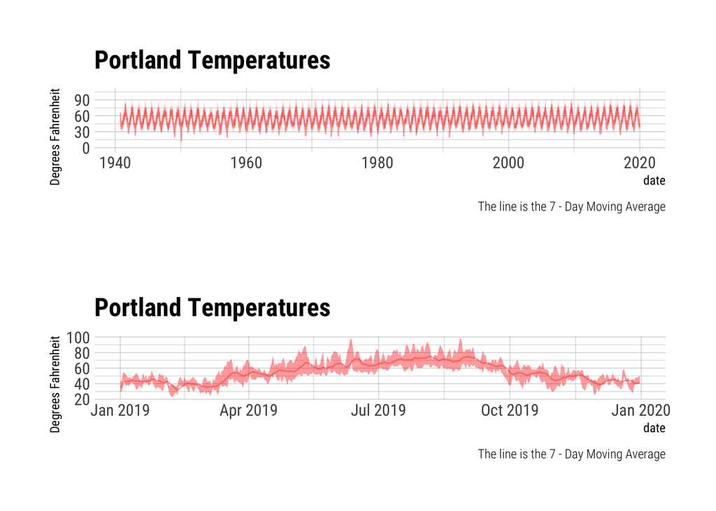

```r
library(slider)
Plot.All <- NWS.Daily.Clean %>%
  mutate(Midpoint = (TX+TN)/2) %>%
  mutate(Mid.Temp = slide_dbl(Midpoint, mean, .before=6)) %>%
  ggplot() +
  aes(x=date) +
  geom_line(aes(y=Mid.Temp, alpha=0.001, color="red")) +
  scale_x_date() +
  geom_ribbon(aes(ymin=TN, ymax=TX), alpha=0.4, fill="red") +
  hrbrthemes::theme_ipsum_rc() + labs(title="Portland Temperatures", y="Degrees Fahrenheit", caption="The line is the 7 - Day Moving Average") +
  guides(alpha="none", color="none")
Plot.Mini <- NWS.Daily.Clean %>%
  filter(date >= as.Date("2019-01-01")) %>%
  mutate(Midpoint = (TX+TN)/2) %>%
  mutate(Mid.Temp = slide_dbl(Midpoint, mean, .before=6)) %>%
  ggplot() +
  aes(x=date) +
  geom_line(aes(y=Mid.Temp, alpha=0.005, color="red")) +  scale_x_date() +
  geom_ribbon(aes(ymin=TN, ymax=TX), alpha=0.4, fill="red") +
  hrbrthemes::theme_ipsum_rc() + labs(title="Portland Temperatures", y="Degrees Fahrenheit", caption="The line is the 7 - Day Moving Average") +
  guides(alpha="none", colour="none")
library(patchwork)
Plot.All / Plot.Mini
```

# References

```r
knitr::write_bib(names(sessionInfo()$otherPkgs), file="bibliography.bib")
```

## References

Firke, Sam. 2021. *Janitor: Simple Tools for Examining and Cleaning Dirty Data*. https://github.com/sfirke/janitor.

Hester, Jim, Hadley Wickham, and Jennifer Bryan. 2022. *Vroom: Read and Write Rectangular Text Data Quickly*. https://CRAN.R-project.org/package=vroom.

Müller, Kirill, and Hadley Wickham. 2022. *Tibble: Simple Data Frames*. https://CRAN.R-project.org/package=tibble.

Pedersen, Thomas Lin. 2022. *Patchwork: The Composer of Plots*. https://CRAN.R-project.org/package=patchwork.

Vaughan, Davis. 2022. *Slider: Sliding Window Functions*. https://CRAN.R-project.org/package=slider.

Wickham, Hadley. 2016. *Ggplot2: Elegant Graphics for Data Analysis*. Springer-Verlag New York. https://ggplot2.tidyverse.org.

———. 2022a. *Forcats: Tools for Working with Categorical Variables (Factors)*. https://CRAN.R-project.org/package=forcats.

———. 2022b. *Stringr: Simple, Consistent Wrappers for Common String Operations*. https://CRAN.R-project.org/package=stringr.

———. 2022c. *Tidyverse: Easily Install and Load the Tidyverse*. https://CRAN.R-project.org/package=tidyverse.

Wickham, Hadley, Mara Averick, Jennifer Bryan, Winston Chang, Lucy D’Agostino McGowan, Romain François, Garrett Grolemund, et al. 2019. “Welcome to the tidyverse.” *Journal of Open Source Software* 4 (43): 1686. https://doi.org/10.21105/joss.01686.

Wickham, Hadley, Winston Chang, Lionel Henry, Thomas Lin Pedersen, Kohske Takahashi, Claus Wilke, Kara Woo, Hiroaki Yutani, and Dewey Dunnington. 2022. *Ggplot2: Create Elegant Data Visualisations Using the Grammar of Graphics*. https://CRAN.R-project.org/package=ggplot2.

Wickham, Hadley, Romain François, Lionel Henry, and Kirill Müller. 2022. *Dplyr: A Grammar of Data Manipulation*. https://CRAN.R-project.org/package=dplyr.

Wickham, Hadley, and Maximilian Girlich. 2022. *Tidyr: Tidy Messy Data*. https://CRAN.R-project.org/package=tidyr.

Wickham, Hadley, and Lionel Henry. 2023. *Purrr: Functional Programming Tools*. https://CRAN.R-project.org/package=purrr.

Wickham, Hadley, Jim Hester, and Jennifer Bryan. 2022. *Readr: Read Rectangular Text Data*. https://CRAN.R-project.org/package=readr.

Wickham, Hadley, and Dana Seidel. 2022. *Scales: Scale Functions for Visualization*. https://CRAN.R-project.org/package=scales.

Xie, Yihui, Joe Cheng, and Xianying Tan. 2022. *DT: A Wrapper of the JavaScript Library DataTables*. https://github.com/rstudio/DT.